# 4. Regression Analysis

```python
from transformers import AutoTokenizer, AutoModelForSequenceClassification
import torch
import pandas as pd
import numpy as np
import seaborn as sns
import matplotlib.pyplot as plt
from sklearn.metrics import accuracy_score, precision_recall_fscore_support, confusion_matrix, classification_report
# Configure font settings
plt.rcParams["font.family"] = "Times New Roman"
plt.rcParams["font.size"] = 12  # or your preferred size
```

```python
df = pd.read_csv("reviews_final.csv")
```

```python
df.describe().T
```

|  | count | mean | std | min | 25% | 50% | 75% | max |
| --- | --- | --- | --- | --- | --- | --- | --- | --- |
| Rating | 2500.0 | 3.000000 | 1.414496 | 1.000000 | 2.000000 | 3.000000 | 4.000000 | 5.000000 |
| Word Count | 2500.0 | 59.604000 | 75.639009 | 11.000000 | 23.000000 | 38.000000 | 67.000000 | 1308.000000 |
| Sentence Count | 2500.0 | 4.858800 | 4.077341 | 1.000000 | 3.000000 | 4.000000 | 6.000000 | 70.000000 |
| Sentiment Score | 2500.0 | 2.895200 | 1.430327 | 1.000000 | 2.000000 | 3.000000 | 4.000000 | 5.000000 |
| Disgust | 2500.0 | 0.211604 | 0.293112 | 0.000405 | 0.012924 | 0.056851 | 0.300108 | 0.990402 |
| Neutral | 2500.0 | 0.353096 | 0.299737 | 0.001324 | 0.070253 | 0.275980 | 0.620802 | 0.964709 |
| Surprise | 2500.0 | 0.092531 | 0.187460 | 0.000488 | 0.008582 | 0.021069 | 0.067939 | 0.982176 |
| Sadness | 2500.0 | 0.119433 | 0.225240 | 0.001245 | 0.007661 | 0.019977 | 0.085001 | 0.991493 |
| Anger | 2500.0 | 0.032762 | 0.083683 | 0.000702 | 0.005819 | 0.010265 | 0.023311 | 0.920049 |
| Fear | 2500.0 | 0.014883 | 0.067555 | 0.000192 | 0.001621 | 0.003335 | 0.007022 | 0.966942 |
| Joy | 2500.0 | 0.175689 | 0.284331 | 0.000265 | 0.003934 | 0.016604 | 0.215667 | 0.988367 |
| Not as Expected | 2500.0 | 0.798806 | 0.280120 | 0.001575 | 0.704460 | 0.947795 | 0.988376 | 0.999607 |
| Damaged | 2500.0 | 0.537600 | 0.374355 | 0.000093 | 0.135360 | 0.586703 | 0.925840 | 0.999201 |
| Returns | 2500.0 | 0.411566 | 0.258180 | 0.000165 | 0.191423 | 0.400198 | 0.608140 | 0.996450 |
| Taste and Flavour | 2500.0 | 0.739552 | 0.255573 | 0.000892 | 0.606079 | 0.842419 | 0.940022 | 0.997584 |
| Size and Quantity | 2500.0 | 0.397051 | 0.272608 | 0.000280 | 0.169777 | 0.349763 | 0.583697 | 0.994523 |
| Freshness | 2500.0 | 0.436469 | 0.246255 | 0.000160 | 0.237904 | 0.462915 | 0.619586 | 0.995169 |
| Price | 2500.0 | 0.594878 | 0.223345 | 0.000219 | 0.457925 | 0.602018 | 0.752274 | 0.998390 |
| Packaging | 2500.0 | 0.361982 | 0.306827 | 0.000095 | 0.086292 | 0.289165 | 0.579973 | 0.998141 |
| Quality | 2500.0 | 0.535146 | 0.364961 | 0.000410 | 0.150327 | 0.582903 | 0.908863 | 0.999004 |
| Delivery | 2500.0 | 0.407135 | 0.239221 | 0.000169 | 0.217720 | 0.397307 | 0.567012 | 0.991957 |
| Ingredients | 2500.0 | 0.409483 | 0.202372 | 0.000506 | 0.266801 | 0.421024 | 0.553744 | 0.997310 |
| Value for Money | 2500.0 | 0.540748 | 0.344151 | 0.000500 | 0.214837 | 0.563888 | 0.887363 | 0.999084 |
| Expiration Date | 2500.0 | 0.211753 | 0.197649 | 0.000123 | 0.069013 | 0.153159 | 0.290268 | 0.994542 |
| Easy to Use | 2500.0 | 0.297786 | 0.329725 | 0.000088 | 0.008903 | 0.134983 | 0.571694 | 0.998966 |

```python
# Drop unnecessary columns for regression (IDs, titles)
df_numeric = df.select_dtypes(include='number')
df_numeric = df_numeric.drop(columns=['Word Count'])

df_numeric.head()
```

|  | Rating | Sentence Count | Sentiment Score | Disgust | Neutral | Surprise | Sadness | Anger | Fear | Joy | ... | Size and Quantity | Freshness | Price | Packaging | Quality | Delivery | Ingredients | Value for Money | Expiration Date | Easy to Use |
| --- | --- | --- | --- | --- | --- | --- | --- | --- | --- | --- | --- | --- | --- | --- | --- | --- | --- | --- | --- | --- | --- |
| 0 | 1 | 4 | 2 | 0.804613 | 0.117591 | 0.036750 | 0.016928 | 0.015843 | 0.005607 | 0.002668 | ... | 0.580697 | 0.563067 | 0.512632 | 0.504350 | 0.479996 | 0.443529 | 0.398306 | 0.274983 | 0.262287 | 0.003500 |
| 1 | 1 | 2 | 2 | 0.016087 | 0.897088 | 0.053865 | 0.013103 | 0.005532 | 0.002959 | 0.011365 | ... | 0.838486 | 0.656657 | 0.761610 | 0.890504 | 0.599424 | 0.631338 | 0.496917 | 0.873846 | 0.421396 | 0.711866 |
| 2 | 1 | 10 | 1 | 0.055551 | 0.011145 | 0.004445 | 0.006217 | 0.920049 | 0.001920 | 0.000672 | ... | 0.187313 | 0.453949 | 0.630233 | 0.970938 | 0.138929 | 0.451631 | 0.424056 | 0.021255 | 0.109231 | 0.003598 |
| 3 | 1 | 4 | 2 | 0.019381 | 0.576999 | 0.027447 | 0.009565 | 0.010700 | 0.001325 | 0.354583 | ... | 0.106066 | 0.110738 | 0.486595 | 0.007563 | 0.010856 | 0.128732 | 0.222780 | 0.553957 | 0.076687 | 0.554640 |
| 4 | 1 | 3 | 2 | 0.146017 | 0.303287 | 0.477158 | 0.031279 | 0.035491 | 0.002224 | 0.004545 | ... | 0.242079 | 0.549498 | 0.553083 | 0.255709 | 0.029213 | 0.489212 | 0.707407 | 0.124269 | 0.232694 | 0.000550 |

5 rows × 24 columns

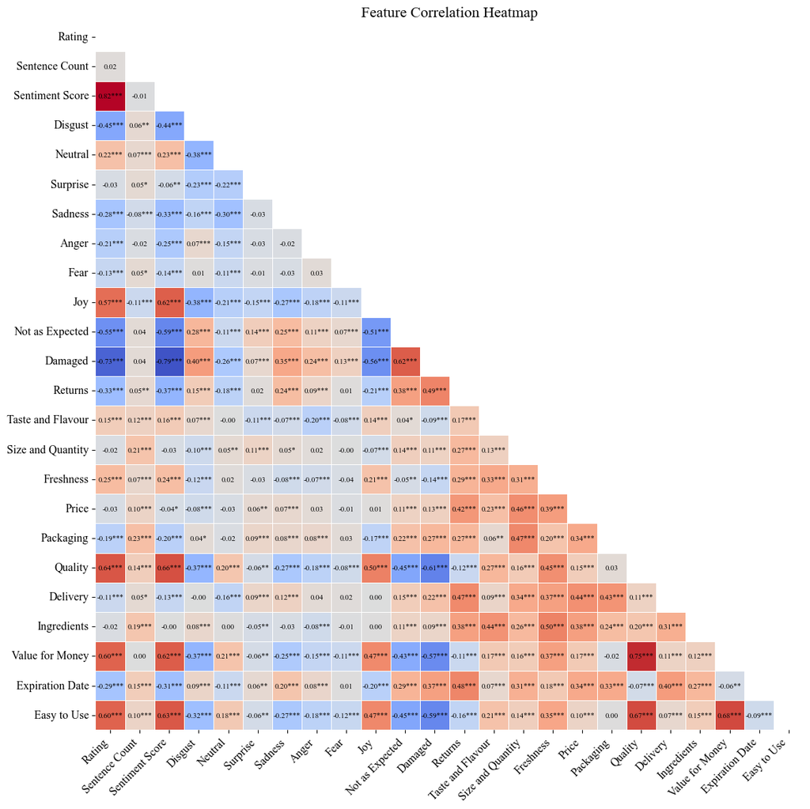

```python
import pandas as pd
import numpy as np
import seaborn as sns
import matplotlib.pyplot as plt
from scipy.stats import pearsonr

# Function to compute p-values matrix
def calculate_pvalues(df):
    pvalues = pd.DataFrame(np.ones((df.shape[1], df.shape[1])), columns=df.columns, index=df.columns)
    for i in range(df.shape[1]):
        for j in range(i+1, df.shape[1]):
            _, p = pearsonr(df.iloc[:, i], df.iloc[:, j])
            pvalues.iloc[i, j] = p
            pvalues.iloc[j, i] = p
    return pvalues

# Calculate correlation and p-values
corr = df_numeric.corr()
pvals = calculate_pvalues(df_numeric)

# Format annotations with asterisks
def format_corr_with_asterisks(corr, pvals):
    annot = corr.copy().astype(str)
    for i in range(corr.shape[0]):
        for j in range(corr.shape[1]):
            r = corr.iloc[i, j]
            p = pvals.iloc[i, j]
            if p < 0.001:
                annot.iloc[i, j] = f"{r:.2f}***"
            elif p < 0.01:
                annot.iloc[i, j] = f"{r:.2f}**"
            elif p < 0.05:
                annot.iloc[i, j] = f"{r:.2f}*"
            else:
                annot.iloc[i, j] = f"{r:.2f}"
    return annot

annot = format_corr_with_asterisks(corr, pvals)

# Set font to Times New Roman
plt.rcParams["font.family"] = "Times New Roman"

# Mask the lower triangle
mask = np.triu(np.ones_like(corr, dtype=bool))

# Plot
plt.figure(figsize=(14, 12))
sns.heatmap(
    corr,
    mask=mask,
    cmap='coolwarm',
    center=0,
    annot=annot,
    fmt="",
    linewidths=0.4,
    square=True,
    cbar=False,   # <---- turn off the colorbar
    #cbar_kws={"shrink": 0.85, "label": "Correlation"},
    annot_kws={"size": 8, "color": "black"}
)

plt.title("Feature Correlation Heatmap", fontsize=16)
plt.xticks(rotation=45, ha='right', fontsize=12)
plt.yticks(fontsize=12)
plt.tight_layout()
# Save as image
plt.savefig("correlation_matrix.png", dpi=300, bbox_inches="tight")
plt.show()
```

In the emotion-based features, each review's emotional profile was represented as a set of probability scores summing to 1 across seven categories (e.g., Joy, Anger, Fear, Disgust, Sadness, Surprise, Neutral). Because these emotion probabilities are compositional by nature, they exhibit perfect multicollinearity—meaning the inclusion of all categories in a linear model would violate the full-rank assumption of ordinary least squares (OLS).

To resolve this, the category Neutral was excluded from the regression model and treated as a reference category. This approach allows the coefficients of the remaining emotion variables to be interpreted as the effect of that emotion relative to a neutral baseline. This is consistent with common practice in regression modeling with compositional or one-hot encoded variables, where one category must be omitted to avoid the “dummy variable trap.”

```python
from sklearn.linear_model import LassoCV
from sklearn.preprocessing import StandardScaler
from sklearn.model_selection import train_test_split
import statsmodels.api as sm

X = df_numeric.drop(columns=['Rating', 'Neutral'])
y = df_numeric['Rating']

X_train, X_test, y_train, y_test = train_test_split(
    X, y, test_size=0.2, random_state=42
)

X_train_sm = sm.add_constant(X_train)
model = sm.OLS(y_train, X_train_sm).fit()

X_test_sm = sm.add_constant(X_test)
y_pred = model.predict(X_test_sm)
```

```python
from statsmodels.stats.diagnostic import het_breuschpagan

# Get residuals and exogenous variables (with constant)
residuals = model.resid
exog = model.model.exog  # includes constant

# Run Breusch-Pagan test
bp_test = het_breuschpagan(residuals, exog)

# Unpack results
bp_stat, bp_pvalue, f_stat, f_pvalue = bp_test

print("Breusch-Pagan test results:")
print(f"  Lagrange Multiplier statistic: {bp_stat:.4f}")
print(f"  p-value (LM): {bp_pvalue:.4f}")
print(f"  F-statistic: {f_stat:.4f}")
print(f"  p-value (F): {f_pvalue:.4f}")
```

```
Breusch-Pagan test results:
  Lagrange Multiplier statistic: 82.4009
  p-value (LM): 0.0000
  F-statistic: 3.8615
  p-value (F): 0.0000
```

```python
from statsmodels.stats.diagnostic import het_white
import statsmodels.api as sm

# Perform White test
white_test = het_white(model.resid, model.model.exog)

# Extract results
labels = ['LM Statistic', 'LM p-value', 'F-statistic', 'F p-value']
results = dict(zip(labels, white_test))

# Print results
print("White Test for Heteroscedasticity:")
for key, value in results.items():
    print(f"{key}: {value:.4f}")
```

```
White Test for Heteroscedasticity:
LM Statistic: 488.5655
LM p-value: 0.0000
F-statistic: 2.0265
F p-value: 0.0000
```

Heteroscedasticity was detected in the residuals (Breusch-Pagan test: LM = 82.40, p < 0.000).

To address this, heteroscedasticity-robust standard errors (HC3) were applied to ensure valid inference and reliable coefficient significance.

Addressing heteroscedasticity in statistical modeling is crucial for ensuring the reliability and validity of regression analyses. Heteroscedasticity, the violation of the homoscedasticity assumption, can lead to inefficient estimates and incorrect inferences if not properly managed. Using heteroscedasticity-consistent standard errors can mitigate the effects of heteroscedasticity without altering the model structure(Kumar, 2023) (Astivia & Zumbo, 2019).

Kumar, N.K., 2023. Autocorrelation and Heteroscedasticity in Regression Analysis. *Journal of Business and Social Science* [Online], 5(1), pp.9–20. Available from: https://doi.org/10.3126/jbss.v5i1.72442.

Olvera Astivia, O. L., & Zumbo, B. D. (2019). Heteroskedasticity in Multiple Regression Analysis: What it is, How to Detect it and How to Solve it with Applications in R and SPSS. *Practical Assessment, Research and Evaluation*, *24*(1), 1. https://doi.org/10.7275/Q5XR-FR95

While HC1 is a common choice, studies have shown that other estimators like HC3 and HC4 often produce smaller errors and are more reliable in the presence of heteroscedasticity and high leverage points. These estimators might be more suitable for NLP models that exhibit these characteristics(T, 2023).

T, N.M., 2023. Heteroscedasticity of unknown form: a comparison of five heteroscedasticity-consistent covariance matrix (hccm) estimators. *Global Journal of Pure and Applied Sciences* [Online], 29(1), pp.83–90. Available from: https://doi.org/10.4314/gjpas.v29i1.10.

```python
model_robust = model.get_robustcov_results(cov_type='HC3')
print(model_robust.summary())
```

```
                            OLS Regression Results
==============================================================================
Dep. Variable:                 Rating   R-squared:                       0.717
Model:                            OLS   Adj. R-squared:                  0.714
Method:                 Least Squares   F-statistic:                     359.8
Date:                Wed, 10 Sep 2025   Prob (F-statistic):               0.00
Time:                        23:20:44   Log-Likelihood:                -2275.6
No. Observations:                2000   AIC:                             4597.
Df Residuals:                    1977   BIC:                             4726.
Df Model:                          22
Covariance Type:                  HC3
=====================================================================================
                        coef    std err          t      P>|t|      [0.025      0.975]
-------------------------------------------------------------------------------------
const                 1.7651      0.157     11.264      0.000       1.458       2.072
Sentence Count        0.0146      0.006      2.379      0.017       0.003       0.027
Sentiment Score       0.4705      0.031     14.950      0.000       0.409       0.532
Disgust              -0.4087      0.087     -4.675      0.000      -0.580      -0.237
Surprise              0.0754      0.108      0.697      0.486      -0.137       0.288
Sadness              -0.0124      0.106     -0.117      0.907      -0.221       0.196
Anger                 0.0943      0.246      0.383      0.701      -0.388       0.576
Fear                 -0.6388      0.301     -2.120      0.034      -1.230      -0.048
Joy                   0.1690      0.078      2.176      0.030       0.017       0.321
Not as Expected      -0.2631      0.082     -3.193      0.001      -0.425      -0.102
Damaged              -0.4282      0.098     -4.389      0.000      -0.620      -0.237
Returns               0.0212      0.098      0.215      0.829      -0.172       0.214
Taste and Flavour     0.1162      0.083      1.399      0.162      -0.047       0.279
Size and Quantity    -0.0293      0.084     -0.350      0.726      -0.193       0.135
Freshness             0.4188      0.089      4.688      0.000       0.244       0.594
Price                 0.0719      0.100      0.717      0.474      -0.125       0.269
Packaging            -0.1021      0.070     -1.458      0.145      -0.239       0.035
Quality               0.2951      0.095      3.120      0.002       0.110       0.481
Delivery             -0.0395      0.101     -0.392      0.695      -0.237       0.158
Ingredients          -0.4868      0.108     -4.507      0.000      -0.699      -0.275
Value for Money       0.2557      0.088      2.912      0.004       0.084       0.428
Expiration Date      -0.4681      0.124     -3.775      0.000      -0.711      -0.225
Easy to Use           0.1562      0.085      1.838      0.066      -0.010       0.323
==============================================================================
Omnibus:                       32.653   Durbin-Watson:                   1.930
Prob(Omnibus):                  0.000   Jarque-Bera (JB):               61.181
Skew:                          -0.031   Prob(JB):                     5.18e-14
Kurtosis:                       3.855   Cond. No.                         105.
==============================================================================

Notes:
[1] Standard Errors are heteroscedasticity robust (HC3)
```

```python
from sklearn.metrics import mean_squared_error, r2_score
import numpy as np

# Mean Squared Error
mse = mean_squared_error(y_test, y_pred)

# Root Mean Squared Error
rmse = np.sqrt(mse)

# R-squared
r2 = r2_score(y_test, y_pred)

print(f"RMSE: {rmse:.3f}, R²: {r2:.3f}")
```

```
RMSE: 0.763, R²: 0.700
```

```python
from statsmodels.stats.outliers_influence import variance_inflation_factor
import pandas as pd
import statsmodels.api as sm

# Create a DataFrame to hold VIF values
vif_df = pd.DataFrame()
vif_df["Variable"] = X_train_sm.columns
vif_df["VIF"] = [variance_inflation_factor(X_train_sm.values, i) for i in range(X_train_sm.shape[1])]

print(vif_df)
```

```
             Variable        VIF
0               const  58.219646
1      Sentence Count   1.211510
2     Sentiment Score   3.829435
3             Disgust   2.013180
4            Surprise   1.276626
5             Sadness   1.579578
6               Anger   1.176678
7                Fear   1.080455
8                 Joy   2.029262
9     Not as Expected   1.911048
10            Damaged   3.933103
11            Returns   2.083682
12  Taste and Flavour   1.466712
13  Size and Quantity   1.580296
14          Freshness   1.906682
15              Price   1.641833
16          Packaging   1.610016
17            Quality   3.336244
18           Delivery   1.721776
19        Ingredients   1.705930
20    Value for Money   2.827241
21    Expiration Date   1.538348
22        Easy to Use   2.456141
```

### Standardize coefficients (z-score scaling)

```python
scaler = StandardScaler()
X_train_scaled = scaler.fit_transform(X_train)
X_test_scaled = scaler.transform(X_test)

# Recreate DataFrames with matching index from y_train / y_test
X_train_scaled_df = pd.DataFrame(X_train_scaled, columns=X_train.columns, index=y_train.index)
X_test_scaled_df = pd.DataFrame(X_test_scaled, columns=X_test.columns, index=y_test.index)

# 3. Add constant for intercept
X_train_scaled_const = sm.add_constant(X_train_scaled_df)
X_test_scaled_const = sm.add_constant(X_test_scaled_df)

# 4. Fit OLS on standardized training data
model_std = sm.OLS(y_train, X_train_scaled_const).fit()

# 5. Predict on standardized test data
y_pred_std = model_std.predict(X_test_scaled_const)

# 6. Print summary

model_std_robust = model_std.get_robustcov_results(cov_type='HC3')

print(model_std_robust.summary())
```

```
                            OLS Regression Results
==============================================================================
Dep. Variable:                 Rating   R-squared:                       0.717
Model:                            OLS   Adj. R-squared:                  0.714
Method:                 Least Squares   F-statistic:                     359.8
Date:                Wed, 10 Sep 2025   Prob (F-statistic):               0.00
Time:                        23:20:45   Log-Likelihood:                -2275.6
No. Observations:                2000   AIC:                             4597.
Df Residuals:                    1977   BIC:                             4726.
Df Model:                          22
Covariance Type:                  HC3
=====================================================================================
                        coef    std err          t      P>|t|      [0.025      0.975]
-------------------------------------------------------------------------------------
const                 2.9955      0.017    175.155      0.000       2.962       3.029
Sentence Count        0.0603      0.025      2.379      0.017       0.011       0.110
Sentiment Score       0.6771      0.045     14.950      0.000       0.588       0.766
Disgust              -0.1198      0.026     -4.675      0.000      -0.170      -0.070
Surprise              0.0141      0.020      0.697      0.486      -0.026       0.054
Sadness              -0.0028      0.024     -0.117      0.907      -0.049       0.044
Anger                 0.0081      0.021      0.383      0.701      -0.033       0.050
Fear                 -0.0459      0.022     -2.120      0.034      -0.088      -0.003
Joy                   0.0482      0.022      2.176      0.030       0.005       0.092
Not as Expected      -0.0743      0.023     -3.193      0.001      -0.120      -0.029
Damaged              -0.1600      0.036     -4.389      0.000      -0.232      -0.089
Returns               0.0054      0.025      0.215      0.829      -0.044       0.055
Taste and Flavour     0.0299      0.021      1.399      0.162      -0.012       0.072
Size and Quantity    -0.0080      0.023     -0.350      0.726      -0.053       0.037
Freshness             0.1022      0.022      4.688      0.000       0.059       0.145
Price                 0.0161      0.022      0.717      0.474      -0.028       0.060
Packaging            -0.0313      0.021     -1.458      0.145      -0.073       0.011
Quality               0.1073      0.034      3.120      0.002       0.040       0.175
Delivery             -0.0094      0.024     -0.392      0.695      -0.057       0.038
Ingredients          -0.0981      0.022     -4.507      0.000      -0.141      -0.055
Value for Money       0.0883      0.030      2.912      0.004       0.029       0.148
Expiration Date      -0.0925      0.025     -3.775      0.000      -0.141      -0.044
Easy to Use           0.0513      0.028      1.838      0.066      -0.003       0.106
==============================================================================
Omnibus:                       32.653   Durbin-Watson:                   1.930
Prob(Omnibus):                  0.000   Jarque-Bera (JB):               61.181
Skew:                          -0.031   Prob(JB):                     5.18e-14
Kurtosis:                       3.855   Cond. No.                         5.37
==============================================================================

Notes:
[1] Standard Errors are heteroscedasticity robust (HC3)
```

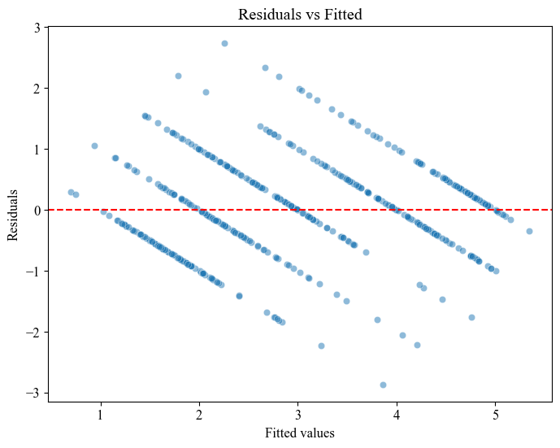

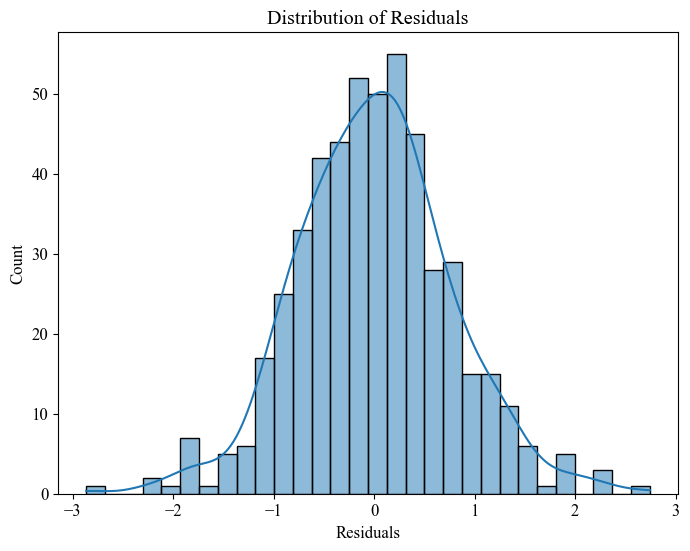

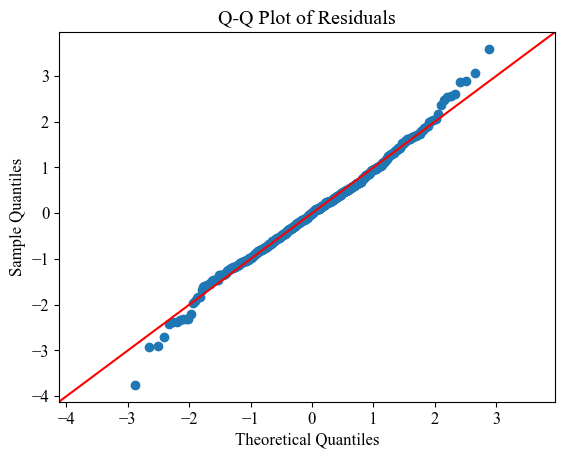

```python
import matplotlib.pyplot as plt
import seaborn as sns
import statsmodels.api as sm

# Calculate residuals
residuals = y_test - y_pred_std

# 1. Residuals vs Fitted
plt.figure(figsize=(8,6))
sns.scatterplot(x=y_pred_std, y=residuals, alpha=0.5)
plt.axhline(0, color='red', linestyle='--')
plt.xlabel("Fitted values")
plt.ylabel("Residuals")
plt.title("Residuals vs Fitted")
plt.show()

# 2. Histogram / KDE of residuals
plt.figure(figsize=(8,6))
sns.histplot(residuals, kde=True, bins=30)
plt.xlabel("Residuals")
plt.title("Distribution of Residuals")
# Save as image
plt.savefig("residuals_distribution.png", dpi=300, bbox_inches="tight")
plt.show()


# 3. Q-Q plot for normality check
sm.qqplot(residuals, line='45', fit=True)
plt.title("Q-Q Plot of Residuals")

# Save as image
plt.savefig("QQ_Residuals.png", dpi=300, bbox_inches="tight")
plt.show()
```

“The regression diagnostics indicate that the model is broadly consistent with the key assumptions of linear regression. The Durbin–Watson statistic (1.93) suggests that the residuals are not serially correlated, and the condition number (5.37) indicates no evidence of multicollinearity. While the Jarque–Bera test was significant, suggesting some departure from normality, the residual distribution was only mildly leptokurtic (kurtosis = 3.85), and with a large sample size (n = 2000) the estimates remain reliable. Evidence of heteroscedasticity was detected, but this was addressed through the use of HC3 heteroscedasticity-robust standard errors, which are widely regarded as an appropriate correction. Taken together, these results suggest that the assumptions of linear regression are sufficiently satisfied for the purposes of inference, albeit with the noted caveats.” The regression model showed no evidence of multicollinearity (condition number = 5.37) and residual independence was supported by a Durbin–Watson statistic close to 2. Although normality and homoscedasticity tests suggested minor deviations, robust (HC3) standard errors were used, ensuring valid inference. Given the large sample size, the model provides reliable estimates for interpreting the impact of individual features on customer ratings.

To better understand what drives customer review ratings, a multiple linear regression model was developed using both emotional features (derived from text analysis) and product-related attributes (e.g., freshness, quality, packaging).

A linear model was selected for its explanatory clarity and interpretability. The inclusion of both emotional and product-specific predictors, along with strong overall model performance (R² = 0.71), suggested no immediate need for polynomial or nonlinear regression. Alternative models, including regularized linear models and Random Forests, were tested and showed similar performance, confirming that linear assumptions were adequate for the task. Regularized models (Lasso and Ridge) were tested alongside OLS to evaluate the presence of multicollinearity and potential model overfitting. However, both models yielded minimal improvement in RMSE and R² (less than 0.5% gain), suggesting that the OLS model was already well-specified and stable. As a result, OLS was retained for its interpretability and explanatory clarity.

### Marginal Effects of Predictors on Rating

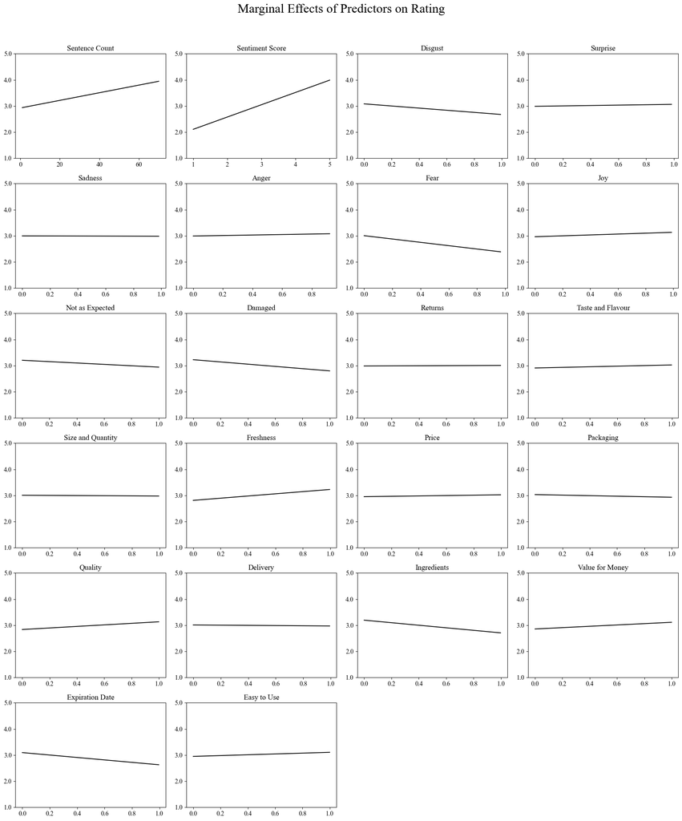

```python
import numpy as np
import pandas as pd
import matplotlib.pyplot as plt
import statsmodels.api as sm

# Define selected features for plotting
selected_features = X_train.columns.tolist()

# ---- MARGINAL PLOTS ----

# Configuration
n_cols = 4
selected = selected_features
n_rows = int(np.ceil(len(selected) / n_cols))

# Get mean row
X_avg = X_train.mean()

# Set up figure
fig, axes = plt.subplots(n_rows, n_cols, figsize=(4.5 * n_cols, 3.5 * n_rows), constrained_layout=True)
axes = axes.flatten()

# Define y-axis format and limits
y_min, y_max = 1, 5
y_ticks = np.linspace(y_min, y_max, 5)

# Loop over selected features
for i, var in enumerate(selected):
    # Create a range for this variable
    var_range = np.linspace(X_train[var].min(), X_train[var].max(), 100)

    # Create 100 copies of the average observation
    X_plot = pd.DataFrame([X_avg] * 100)
    X_plot[var] = var_range

    # Add constant manually
    X_plot.insert(0, 'const', 1)

    # Match column order with model input
    X_plot = X_plot[model.model.exog_names]

    # Predict ratings
    y_plot_pred = model.predict(X_plot)

    # Plot
    ax = axes[i]
    ax.plot(var_range, y_plot_pred, color='black')
    ax.set_title(var, fontsize=14)
    ax.set_xlabel('')
    ax.set_ylabel('')
    ax.grid(False)
    ax.set_ylim(y_min, y_max)
    ax.set_yticks(y_ticks)
    ax.set_yticklabels([f'{ytick:.1f}' for ytick in y_ticks])

# Remove unused axes
for j in range(len(selected), len(axes)):
    fig.delaxes(axes[j])

# Global title
plt.suptitle('Marginal Effects of Predictors on Rating', fontsize=24, y=1.02)
plt.tight_layout()
# Save as image
plt.savefig("Marginal Plots.png", dpi=300, bbox_inches="tight")
plt.show()
```

```
Significant predictors (p < 0.05): ['Sentence Count', 'Sentiment Score', 'Disgust', 'Fear', 'Joy', 'Not as Expected', 'Damaged', 'Freshness', 'Quality', 'Ingredients', 'Value for Money', 'Expiration Date']
```

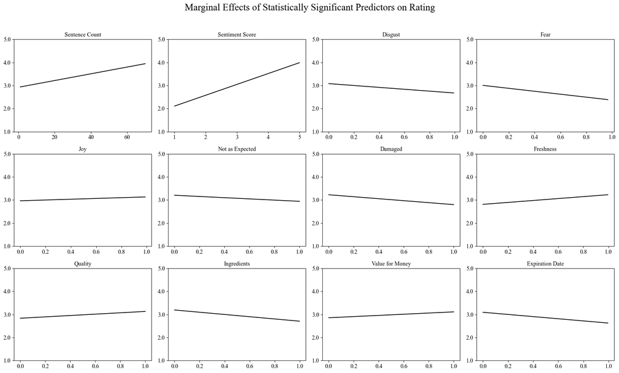

```python
import numpy as np
import pandas as pd
import matplotlib.pyplot as plt
import statsmodels.api as sm

# Get p-values from the fitted model
pvals = model.pvalues.drop("const", errors="ignore")  # drop intercept
alpha = 0.05  # significance threshold

# Keep only statistically significant predictors
significant_features = pvals[pvals < alpha].index.tolist()

print(f"Significant predictors (p < {alpha}): {significant_features}")

# ---- MARGINAL PLOTS ----

# Configuration
n_cols = 4
selected = significant_features
n_rows = int(np.ceil(len(selected) / n_cols))

# Get mean row
X_avg = X_train.mean()

# Set up figure
fig, axes = plt.subplots(n_rows, n_cols, figsize=(4.5 * n_cols, 3.5 * n_rows), constrained_layout=True)
axes = axes.flatten()

# Define y-axis format and limits
y_min, y_max = 1, 5
y_ticks = np.linspace(y_min, y_max, 5)

# Loop over significant features
for i, var in enumerate(selected):
    # Create a range for this variable
    var_range = np.linspace(X_train[var].min(), X_train[var].max(), 100)

    # Create 100 copies of the average observation
    X_plot = pd.DataFrame([X_avg] * 100)
    X_plot[var] = var_range

    # Add constant manually
    X_plot.insert(0, 'const', 1)

    # Match column order with model input
    X_plot = X_plot[model.model.exog_names]

    # Predict ratings
    y_plot_pred = model.predict(X_plot)

    # Plot
    ax = axes[i]
    ax.plot(var_range, y_plot_pred, color='black')
    ax.set_title(f"{var}", fontsize=12)  # show p-value in title
    ax.set_xlabel('')
    ax.set_ylabel('')
    ax.grid(False)
    ax.set_ylim(y_min, y_max)
    ax.set_yticks(y_ticks)
    ax.set_yticklabels([f'{ytick:.1f}' for ytick in y_ticks])

# Remove unused axes
for j in range(len(selected), len(axes)):
    fig.delaxes(axes[j])

# Global title
plt.suptitle('Marginal Effects of Statistically Significant Predictors on Rating', fontsize=20, y=1.02)
plt.tight_layout()
plt.savefig("Marginal_Plots_Significant.png", dpi=300, bbox_inches="tight")
plt.show()
```

```python
from sklearn.linear_model import LinearRegression, RidgeCV, LassoCV
from sklearn.ensemble import RandomForestRegressor
from sklearn.metrics import mean_squared_error, r2_score
from sklearn.model_selection import train_test_split

models = {
    "OLS": LinearRegression(),
    "Ridge": RidgeCV(alphas=[0.1, 1.0, 10.0]),
    "Lasso": LassoCV(cv=5),
    "RandomForest": RandomForestRegressor(n_estimators=100, random_state=0)
}

for name, model in models.items():
    model.fit(X_train, y_train)
    preds = model.predict(X_test)
    mse = mean_squared_error(y_test, preds)
    rmse = np.sqrt(mse)
    r2 = r2_score(y_test, preds)
    print(f"{name}: MSE = {mse:.3f}, RMSE = {rmse:.3f}, R² = {r2:.3f}")
```

```
OLS: MSE = 0.583, RMSE = 0.763, R² = 0.700
Ridge: MSE = 0.574, RMSE = 0.757, R² = 0.705
Lasso: MSE = 0.574, RMSE = 0.758, R² = 0.704
RandomForest: MSE = 0.556, RMSE = 0.745, R² = 0.714
```

To evaluate the predictive performance of the model and ensure robustness, several regression algorithms were implemented and compared. These included a standard Ordinary Least Squares (OLS) linear regression, as well as regularized alternatives — Ridge and Lasso regression — which introduce penalties to reduce overfitting and multicollinearity. Additionally, a Random Forest Regressor was tested as a non-linear, ensemble-based approach capable of capturing complex patterns in the data.

All models were trained on the same training subset and evaluated on a held-out test set using two key metrics: the Root Mean Squared Error (RMSE), which quantifies average prediction error, and R² (coefficient of determination), which reflects the proportion of variance in review ratings explained by the model.

Regularization parameters for Ridge (α = 0.1, 1.0, 10.0) and Lasso (with 5-fold cross-validation) were selected to allow automatic tuning of model complexity. For the Random Forest, 100 decision trees were used with a fixed random seed to ensure reproducibility.

This multi-model comparison not only enables the identification of the best-performing algorithm but also strengthens the validity of the findings by confirming whether the predictive signal in the emotional and textual features is consistent across different types of models.

### Justification for Excluding Sentiment–Topic Interactions

Incorporating interaction features into regression models can significantly enhance their predictive power by capturing complex relationships between variables that are not apparent when considering individual effects alone.

Mikucka, M., Sarracino, F. and Dubrow, J.K., 2015. Costs and Benefits of Including or Omitting Interaction Terms: A Monte Carlo Simulation. *Sociological Methods & Research* [Online], p.0. Available from: https://dial.uclouvain.be/pr/boreal/object/boreal:171002.

The inclusion of interaction terms can enhance the predictive power of a model by capturing complex relationships between variables. However, wrongly omitting interaction terms can lead to a loss of adjusted R² and predictive accuracy, particularly when dealing with strongly correlated continuous variables(Mikucka et al., 2015).

Although sentiment–topic interaction terms could be used in predictive modelling, they are not appropriate in this context where the aim is to interpret how features contribute to ratings. In this study, sentiment is measured as a global score across the entire review, while topic probabilities indicate the overall presence of each theme within the same document. Interacting these variables implicitly assumes that sentiment can be accurately attributed to individual topics, which is not supported by the data structure.

This approach lacks construct validity, as it conflates global affect with thematic content without a clear or reliable linkage between the two. It also introduces interpretive ambiguity, since sentiment expressed in a review may relate only to a subset of the discussed topics, and the model cannot distinguish which sentiment belongs to which topic. As both sentiment and topic proportions are latent, document-level measures, the interaction terms do not represent meaningful causal relationships and may instead reflect statistical artefacts.

For these reasons, sentiment–topic interactions were not included in the model. A more robust approach would involve aligning sentiment and topics at the sentence or phrase level, which is beyond the scope of this study but presents a valuable direction for future research.

The inclusion of interaction terms can enhance the predictive power of a model by capturing complex relationships between variables. However, wrongly omitting interaction terms can lead to a loss of adjusted R² and predictive accuracy, particularly when dealing with strongly correlated continuous variables(Mikucka et al., 2015).

Mikucka, M., Sarracino, F., & Dubrow, J. K. (2015). Costs and Benefits of Including or Omitting Interaction Terms: A Monte Carlo Simulation. *Sociological Methods & Research*, 0. https://dial.uclouvain.be/pr/boreal/object/boreal:171002

```python
# Step 6: Display standardized coefficients (excluding intercept)
standardized_coefs = model_std.params.drop("const").sort_values(key=abs, ascending=False)

print("Standardized Coefficients (sorted by absolute value):\n")
print(standardized_coefs)
```

```
Standardized Coefficients (sorted by absolute value):

Sentiment Score      0.677120
Damaged             -0.160027
Disgust             -0.119829
Quality              0.107331
Freshness            0.102194
Ingredients         -0.098084
Expiration Date     -0.092526
Value for Money      0.088305
Not as Expected     -0.074324
Sentence Count       0.060345
Easy to Use          0.051349
Joy                  0.048196
Fear                -0.045870
Packaging           -0.031332
Taste and Flavour    0.029923
Price                0.016068
Surprise             0.014107
Delivery            -0.009450
Anger                0.008142
Size and Quantity   -0.007959
Returns              0.005442
Sadness             -0.002782
dtype: float64
```

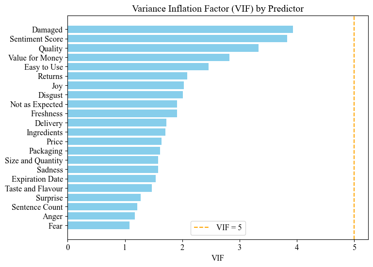

```python
import matplotlib.pyplot as plt
import numpy as np

# Drop the constant
vif_df_no_const = vif_df[vif_df["Variable"] != "const"]

# Sort for readability
vif_df_sorted = vif_df_no_const.sort_values("VIF", ascending=True)

# Assign colours based on thresholds
colours = np.where(vif_df_sorted["VIF"] > 10, "red",
           np.where(vif_df_sorted["VIF"] > 5, "orange", "skyblue"))

plt.figure(figsize=(8, 6))
plt.barh(vif_df_sorted["Variable"], vif_df_sorted["VIF"], color=colours)
plt.axvline(x=5, color="orange", linestyle="--", label="VIF = 5")
#plt.axvline(x=10, color="red", linestyle="--", label="VIF = 10")
plt.xlabel("VIF")
plt.ylabel("")
plt.title("Variance Inflation Factor (VIF) by Predictor")
plt.legend()
# Save as image
plt.savefig("VIF_plot.png", dpi=300, bbox_inches="tight")
plt.show()
```

“The regression diagnostics indicate that the model is broadly consistent with the key assumptions of linear regression. The Durbin–Watson statistic (1.93) suggests that the residuals are not serially correlated, and the condition number (5.37) indicates no evidence of multicollinearity. While the Jarque–Bera test was significant, suggesting some departure from normality, the residual distribution was only mildly leptokurtic (kurtosis = 3.85), and with a large sample size (n = 2000) the estimates remain reliable. Evidence of heteroscedasticity was detected, but this was addressed through the use of HC3 heteroscedasticity-robust standard errors, which are widely regarded as an appropriate correction. Taken together, these results suggest that the assumptions of linear regression are sufficiently satisfied for the purposes of inference, albeit with the noted caveats.”